# Microbiome analysis - data prep

Maureen A. Carey

09/01/2020

Metadata variables: Metadata variables included age-related information (month/year of birth, age in days), socio-economic status (income, perceived food deficit), time of collection (month, year, amount of rainfall that month), the child’s home conditions (presence of an indoor drain, drinking water source, water treatment method, number of children under the age of 5 years), coinfection status (positive qPCR for Giardia spp. or E. histolytica), repeat infection v. primary infection, and growth status (z-scores for weight-for-age, height-for-age, weight-for-height, and body mass index for age). These are known to influence the development of diarrhea broadly or the acquisition of Cryptosporidium (Korpe et al. 2016; Steiner et al. 2018; Mondal et al. 2012)

Code for reference: /Users/maureencarey/local_documents/work/crypto_microbiome/data_cannot_be_shared/open_and_save_all_data.Rmd to generate /Users/maureencarey/local_documents/work/crypto_microbiome/data_cannot_be_shared/data.RData

The above code processes the private patient metadata and so cannot be shared at this point.

# Generate supplemental file 1D to get read counts

```r
p = ggplot(read_counts_df) + geom_histogram(aes(x = value)) + facet_wrap(~variable, nrow = 1) + ylab('samples') + xlab('reads') +
  geom_vline(data = read_count_stats_df, aes(xintercept = mean), color = "red", linetype = "dashed") +
  theme(axis.text.x = element_text(size = 6))
ggsave("/Users/maureencarey/local_documents/work/crypto_microbiome/cryptosporidium_microbiome/figures/SFig1D_read_counts.png",
       p, width = 8, height = 2, dpi = 600)
```

# Sample numbers

Total (raw) reads: 48146401

Mean (raw) reads per sample: 118295.8255528

Median (raw) reads per sample: 121519

Total (filtered) reads per sample: 23088840

Mean (filtered) reads per sample: 59202.1538462

Median (filtered) reads per sample: 58873

Total samples (excluding controls): 392

# Plot positive controls (Supplemental Figure 1A-B)

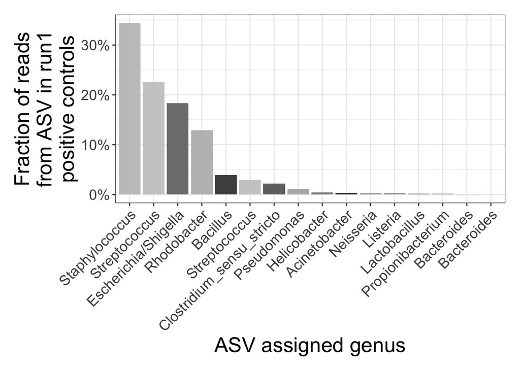

```r
# run 1
rare_min = 10000
readsumsdf = plot_run1
p1 = ggplot(readsumsdf,
           aes(x = names, y = nreads/(rare_min*nrow(sample_data(pos_controls1))), fill=genus)) + geom_bar(stat="identity") + theme(axis.text.x = element_text(size=14,angle=45,hjust=1),
              axis.text.y = element_text(size=14),
              axis.title.x = element_text(size=20),
              axis.title.y = element_text(size=20),
              plot.margin=unit(c(.5,.5,.5,.5),"cm")) +
  labs(y="Fraction of reads\nfrom ASV in run1\npositive controls", x="ASV assigned genus") +
  scale_x_discrete(labels = readsumsdf$genus) +
  scale_fill_grey() + guides(fill = F) + scale_y_continuous(labels = scales::percent)
p1
```

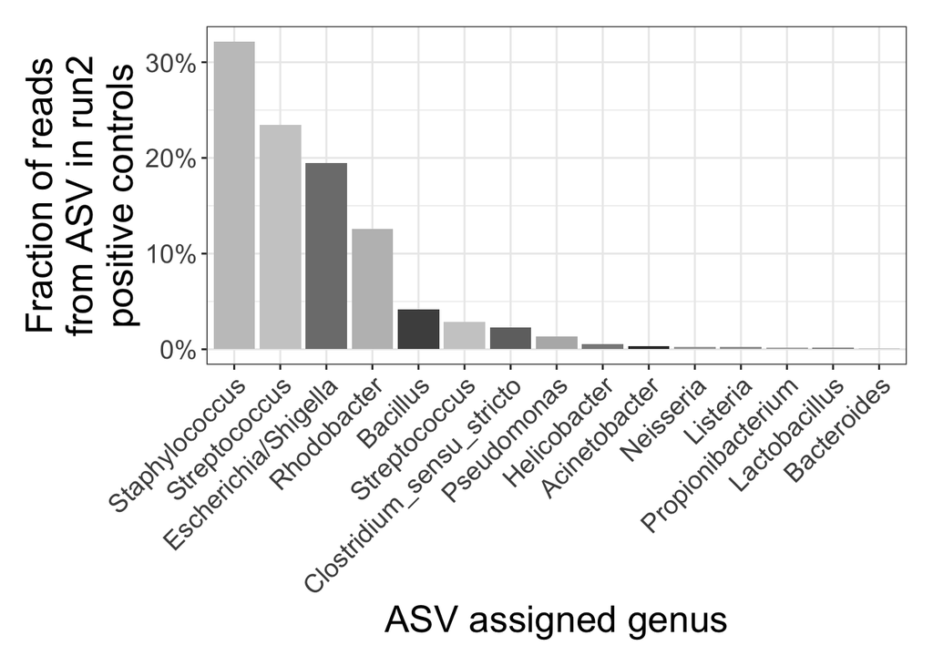

```r
ggsave("/Users/maureencarey/local_documents/work/crypto_microbiome/cryptosporidium_microbiome/figures/SFig1A_abundant_asvs_run1_pos_controls.png",
plot=p1, width = 5.6,height = 4.2,units = "in",dpi = 300)

# run 2
readsumsdf = plot_run2
p1 = ggplot(readsumsdf,
           aes(x = names, y = nreads/(rare_min*nrow(sample_data(pos_controls2))), fill=genus)) + geom_bar(stat="identity") + theme(axis.text.x = element_text(size=14,angle=45,hjust=1),
              axis.text.y = element_text(size=14),
              axis.title.x = element_text(size=20),
              axis.title.y = element_text(size=20),
              plot.margin=unit(c(.5,.5,.5,.5),"cm")) +
  labs(y="Fraction of reads\nfrom ASV in run2\npositive controls", x="ASV assigned genus") +
  scale_x_discrete(labels = readsumsdf$genus) +
  scale_fill_grey() + guides(fill = F) + scale_y_continuous(labels = scales::percent)
p1
```

```r
ggsave("/Users/maureencarey/local_documents/work/crypto_microbiome/cryptosporidium_microbiome/figures/SFig1B_abundant_asvs_run2_pos_controls.png", plot=p1, width = 5.5,height = 4.2,units = "in",dpi = 300)
```

# Sample numbers (prior to filtration due to correct pairing)

Number of children: 82

Total reads: 5867821

Mean reads per sample: 27809.5781991

Median reads per sample: 27379

## Plot Ct data

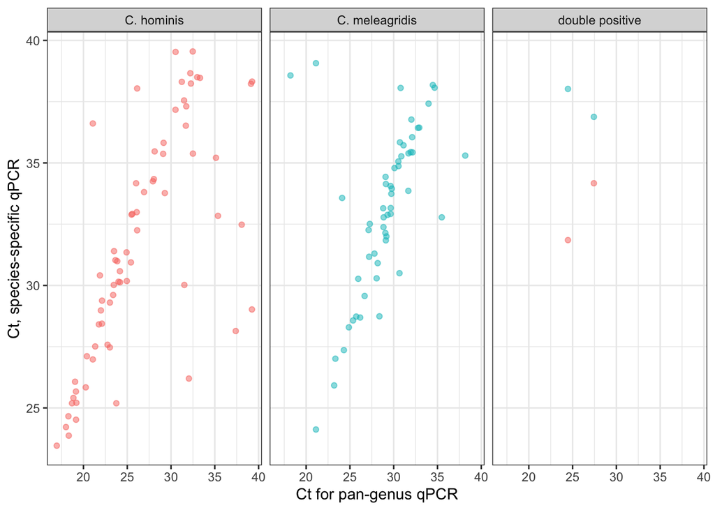

```r
df = ct_df

df %>%
  ggplot() +
  geom_point(aes(x = Pan_crypto, y = value, color = variable),alpha = 0.5) + xlab('Ct for pan-genus qPCR')+
  facet_wrap(~infected_use) + ylab('Ct, species-specific qPCR') +guides(color = F)
```

### Redo figure with Cts

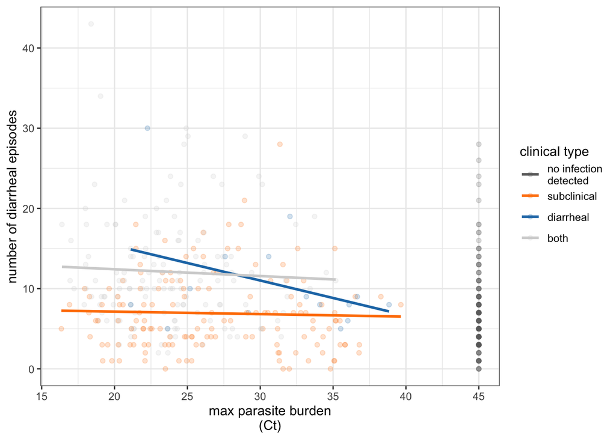

```r
df_plot = ct_updated_df

colors_temp = colors; colors_temp['no infection\ndetected'] = "#666666"
p = ggplot(df_plot %>% dplyr::rename(`clinical type` = TYPE), aes(x = min_ct_overall, y = n_diar,color = `clinical type`)) +
     geom_point(alpha = .2) + stat_smooth(method = "glm",se = F)+scale_color_manual(values = colors_temp) +
  xlab('max parasite burden\n(Ct)') + ylab('number of diarrheal episodes')
p
```

# Sample numbers (AFTER filtration due to correct pairing)

Number of children: 72

Number of samples: 182

Total number of taxa: 895

# Supplemental Figure 4

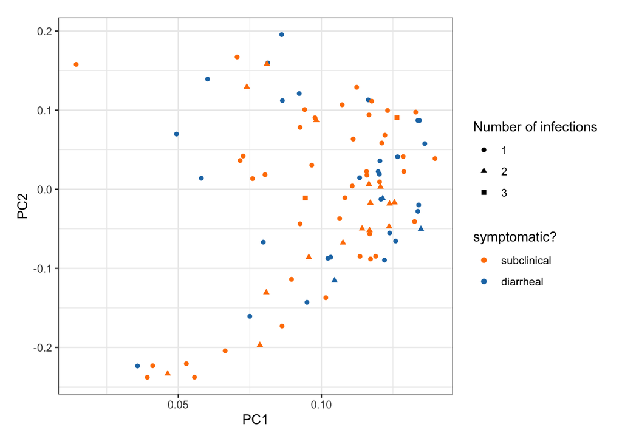

```r
ggplot(axis_location, aes(x = PC1, y = PC2, color = symptomatic, shape = Number.of.crypto.positive.events)) +
  geom_point() +
  scale_color_manual(values = c(colors["diarrheal"],colors["subclinical"]))+ # 12 is diarrhea, 1,2 are pre
  theme(strip.text.x=element_text(size=20,face="bold"),
        plot.margin=unit(c(.5,.5,.5,.5),"cm")) +
  labs(color = "symptomatic?", shape = "Number of infections")
```

```r
ggsave("/Users/maureencarey/local_documents/work/crypto_microbiome/cryptosporidium_microbiome/figures/SFig4_pcoa_change_mirpur.png",  width = 5.4,height = 3,units = "in",dpi = 600)
```

# Table 1

```r
ps_raw = readRDS("/Users/maureencarey/local_documents/work/crypto_microbiome/cryptosporidium_microbiome/results/ps_2020_08_12.rds")
table(sample_data(subset_samples(ps_raw, Site == 1))$Clinical.type)
```

```
##
##    1    2    3   10   12  100  200 1000
##   77   34    3   76   35    3    3    4
```

```r
table(sample_data(subset_samples(ps_raw, Site == 2))$Clinical.type)
```

```
##
##    1    2    3   10   12  200 1000
##   67    1    2   68    1    2    4
```

```r
length(sample_data(subset_samples(ps_raw, Site == 1))$Clinical.type)
```

```
## [1] 235
```

```r
length(sample_data(subset_samples(ps_raw, Site == 2))$Clinical.type)
```

```
## [1] 145
```

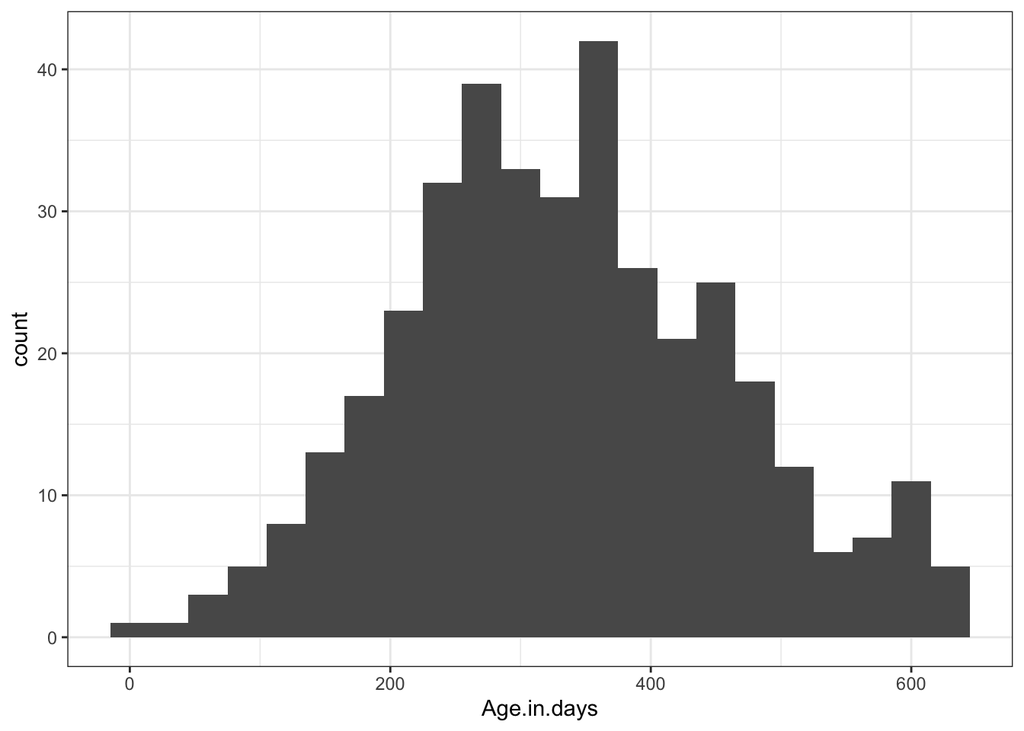

```r
ggplot(as(sample_data(ps_raw),"data.frame"), aes(x = Age.in.days)) +
  geom_histogram(binwidth = 30)
```

```r
length(unique(sample_data(ps_rare_diff)$Child.ID))
```

```
## [1] 72
```

```r
length((sample_data(ps_rare_diff)$Child.ID))
```

```
## [1] 182
```

```r
temp  = as(sample_data(subset_samples(ps_rare_diff, pre_detection == F )),"data.frame") %>% select(Child.ID, Number.of.crypto.positive.events) %>% tibble::rownames_to_column('rown') %>% select(-rown) %>% group_by(Child.ID) %>% top_n(n=1)
table(temp$Number.of.crypto.positive.events)
```

```
##
##  1  2  3
## 53 17  2
```

```r
temp  = as(sample_data(subset_samples(ps_rare_diff, pre_detection == F & symptomatic == F )),"data.frame") %>% select(Child.ID, Number.of.crypto.positive.events)
table(temp$Number.of.crypto.positive.events)
```

```
##
##  1  2  3
## 42 16  2
```

```r
temp  = as(sample_data(subset_samples(ps_rare_diff, pre_detection == F & symptomatic == T )),"data.frame") %>% select(Child.ID, Number.of.crypto.positive.events)
table(temp$Number.of.crypto.positive.events)
```

```
##
##  1  2
## 28  3
```

```r
temp  = as(sample_data(subset_samples(ps_rare_diff, pre_detection == F)),"data.frame") %>% select(Child.ID, Number.of.crypto.positive.events)
table(temp$Number.of.crypto.positive.events)
```

```
##
##  1  2  3
## 70 19  2
```

```r
sample_data(ps_rare_diff)$Date.of.collection %>% min()
```

```
## [1] "2015-01-12"
```

```r
sample_data(ps_rare_diff)$Date.of.collection %>% max()
```

```
## [1] "2016-05-31"
```

```r
table(merge(as(sample_data(subset_samples(ps_rare_diff, pre_detection == F )),"data.frame")%>% select(Child.ID) %>% distinct(),
            burden_sex, by.x = 'Child.ID', by.y = "SID", all.x = T)$SEX)
```

```
##
##  1  2
## 28 44
```

```r
#1 = male, 2 = female


mean(sample_data(subset_samples(ps_rare_diff, symptomatic == T & pre_detection == F))$Age.in.days)
```

```
## [1] 321.9677
```

```r
sd(sample_data(subset_samples(ps_rare_diff, symptomatic == T & pre_detection == F))$Age.in.days)
```

```
## [1] 136.2841
```

```r
mean(sample_data(subset_samples(ps_rare_diff, symptomatic == F & pre_detection == F))$Age.in.days)
```

```
## [1] 362.5333
```

```r
sd(sample_data(subset_samples(ps_rare_diff, symptomatic == F & pre_detection == F))$Age.in.days)
```

```
## [1] 128.8301
```

```r
mean(sample_data(subset_samples(ps_rare_diff, pre_detection == F))$Age.in.days)
```

```
## [1] 348.7143
```

```r
sd(sample_data(subset_samples(ps_rare_diff, pre_detection == F))$Age.in.days)
```

```
## [1] 132.0804
```

```r
t.test(sample_data(subset_samples(ps_rare_diff, symptomatic == T & pre_detection == F))$Age.in.days, sample_data(subset_samples(ps_rare_diff, symptomatic == F & pre_detection == F))$Age.in.days)
```

```
##
##  Welch Two Sample t-test
##
## data:  sample_data(subset_samples(ps_rare_diff, symptomatic == T & pre_detection ==  and sample_data(subset_samples(ps_rare_diff, symptomatic == F & pre_detection ==     F))$Age.in.days and     F))$Age.in.days
## t = -1.3708, df = 57.829, p-value = 0.1757
## alternative hypothesis: true difference in means is not equal to 0
## 95 percent confidence interval:
##  -99.80667  18.67549
## sample estimates:
## mean of x mean of y
##  321.9677  362.5333
```

```r
mean(sample_data(subset_samples(ps_rare_diff, symptomatic == T & pre_detection == F))$Pan_crypto)
```

```
## [1] 29.87161
```

```r
sd(sample_data(subset_samples(ps_rare_diff, symptomatic == T & pre_detection == F))$Pan_crypto)
```

```
## [1] 7.290736
```

```r
mean(sample_data(subset_samples(ps_rare_diff, symptomatic == F & pre_detection == F))$Pan_crypto)
```

```
## [1] 28.62483
```

```r
sd(sample_data(subset_samples(ps_rare_diff, symptomatic == F & pre_detection == F))$Pan_crypto)
```

```
## [1] 6.160137
```

```r
mean(sample_data(subset_samples(ps_rare_diff, pre_detection == F))$Pan_crypto)
```

```
## [1] 29.04956
```

```r
sd(sample_data(subset_samples(ps_rare_diff, pre_detection == F))$Pan_crypto)
```

```
## [1] 6.553462
```

```r
t.test(sample_data(subset_samples(ps_rare_diff, symptomatic == T & pre_detection == F))$Pan_crypto, sample_data(subset_samples(ps_rare_diff, symptomatic == F & pre_detection == F))$Pan_crypto)
```

```
##
##  Welch Two Sample t-test
##
## data:  sample_data(subset_samples(ps_rare_diff, symptomatic == T & pre_detection ==  and sample_data(subset_samples(ps_rare_diff, symptomatic == F & pre_detection ==     F))$Pan_crypto and     F))$Pan_crypto
## t = 0.81381, df = 52.575, p-value = 0.4194
## alternative hypothesis: true difference in means is not equal to 0
## 95 percent confidence interval:
##  -1.826670  4.320229
## sample estimates:
## mean of x mean of y
##  29.87161  28.62483
```

```r
nrow(sample_data(subset_samples(ps_rare_diff, symptomatic == T & pre_detection == F)))
```

```
## [1] 31
```

```r
nrow(sample_data(subset_samples(ps_rare_diff, symptomatic == F & pre_detection == F)))
```

```
## [1] 60
```

```r
nrow(sample_data(subset_samples(ps_rare_diff, symptomatic == T & pre_detection == T)))
```

```
## [1] 31
```

```r
nrow(sample_data(subset_samples(ps_rare_diff, symptomatic == F & pre_detection == T)))
```

```
## [1] 60
```

```r
nrow(sample_data((ps_rare_diff)))
```

```
## [1] 182
```

```r
table(sample_data(subset_samples(ps_rare_diff, pre_detection == F))$Number.of.crypto.positive.events)
```

```
##
##  1  2  3
## 70 19  2
```

```r
table(sample_data(subset_samples(ps_rare_diff, pre_detection == F & symptomatic == F))$Number.of.crypto.positive.events)
```

```
##
##  1  2  3
## 42 16  2
```

```r
table(sample_data(subset_samples(ps_rare_diff, pre_detection == F & symptomatic == T))$Number.of.crypto.positive.events)
```

```
##
##  1  2
## 28  3
```

```r
t1 = as(sample_data(subset_samples(ps_rare_diff, pre_detection == F & symptomatic == T)), "data.frame") %>%
  select(Child.ID,Age.in.days,age_at_surv) %>%
  mutate(age_diff = Age.in.days- age_at_surv) %>%
  select(age_diff)
mean(t1$age_diff)
```

```
## [1] 19.19355
```

```r
sd(t1$age_diff)
```

```
## [1] 9.086324
```

```r
t2 = as(sample_data(subset_samples(ps_rare_diff, pre_detection == F & symptomatic == F)), "data.frame") %>%
  select(Child.ID,Age.in.days,age_at_surv) %>%
  mutate(age_diff = Age.in.days- age_at_surv) %>%
  select(age_diff)
mean(t2$age_diff)
```

```
## [1] 31.1
```

```r
sd(t2$age_diff)
```

```
## [1] 4.568499
```

```r
t.test(t1$age_diff,t2$age_diff)
```

```
##
##  Welch Two Sample t-test
##
## data:  t1$age_diff and t2$age_diff
## t = -6.8615, df = 38.019, p-value = 0.00000003779
## alternative hypothesis: true difference in means is not equal to 0
## 95 percent confidence interval:
##  -15.419241  -8.393662
## sample estimates:
## mean of x mean of y
##  19.19355  31.10000
```

```r
t3 = as(sample_data(subset_samples(ps_rare_diff, pre_detection == F)), "data.frame") %>%
  select(Child.ID,Age.in.days,age_at_surv) %>%
  mutate(age_diff = Age.in.days- age_at_surv) %>%
  select(age_diff)
mean(t3$age_diff)
```

```
## [1] 27.04396
```

```r
sd(t3$age_diff)
```

```
## [1] 8.567266
```

```r
min(t3$age_diff)
```

```
## [1] 1
```

```r
max(t3$age_diff)
```

```
## [1] 41
```

Species

```r
#all
ifelse(sample_data(subset_samples(ps_rare_diff, pre_detection == F))$LIB13.C..hominis<40,1,0) %>% table()
```

```
## .
##  0  1
## 37 54
```

```r
ifelse(sample_data(subset_samples(ps_rare_diff, pre_detection == F))$C..mel.y<40,1,0) %>% table()
```

```
## .
##  0  1
## 85  6
```

```r
ifelse(sample_data(subset_samples(ps_rare_diff, pre_detection == F))$Pan_crypto<40,1,0) %>% table()
```

```
## .
##  1
## 91
```

```r
# diarrheal
ifelse(sample_data(subset_samples(ps_rare_diff, pre_detection == F & symptomatic == T))$LIB13.C..hominis<40,1,0) %>% table()
```

```
## .
##  0  1
## 13 18
```

```r
ifelse(sample_data(subset_samples(ps_rare_diff, pre_detection == F & symptomatic == T))$C..mel.y<40,1,0) %>% table()
```

```
## .
##  0  1
## 29  2
```

```r
ifelse(sample_data(subset_samples(ps_rare_diff, pre_detection == F & symptomatic == T))$Pan_crypto<40,1,0) %>% table()
```

```
## .
##  1
## 31
```

```r
# subclin
ifelse(sample_data(subset_samples(ps_rare_diff, pre_detection == F & symptomatic == F))$LIB13.C..hominis<40,1,0) %>% table()
```

```
## .
##  0  1
## 24 36
```

```r
ifelse(sample_data(subset_samples(ps_rare_diff, pre_detection == F & symptomatic == F))$C..mel.y<40,1,0) %>% table()
```

```
## .
##  0  1
## 56  4
```

```r
ifelse(sample_data(subset_samples(ps_rare_diff, pre_detection == F & symptomatic == F))$Pan_crypto<40,1,0) %>% table()
```

```
## .
##  1
## 60
```

How many ASVs map to Prevotella? (For Fig 3 caption)

```r
ntaxa(subset_taxa(ps_rare_diff, Genus == "Prevotella"))
```

```
## [1] 98
```

```r
ntaxa(subset_taxa(ps_rare_diff, Genus == "Bifidobacterium"))
```

```
## [1] 15
```

```r
ntaxa(subset_taxa(ps_rare_diff, Genus == "Megasphaera"))
```

```
## [1] 20
```

```r
ntaxa(subset_taxa(ps, Genus == "Megasphaera"))
```

```
## [1] 31
```